# Industrial Impact on Housing Prices in Western Kentucky

Brad Brauser

6/25/2023

## Introduction

In the western Kentucky area, the impact of proximity to industrial areas on property pricing is a significant concern. This project aims to examine how residential properties’ value is affected by their proximity to factories, packaging facilities, and other industries. By analyzing factors such as distance, pollution levels, and market dynamics, we seek to provide valuable insights for homeowners, real estate agents, and policymakers. Understanding the correlation between industrial proximity and property prices in this region is crucial for informed decision-making regarding real estate investments and urban planning.

## Literature Review

Although there is limited specific literature on the impact of industrial areas on property pricing in western Kentucky, studies conducted in other regions shed light on similar issues. One such study examined the property prices in Bordeaux, Dunkirk, and Rouen, which have hazardous chemical and petrochemical industries in or near the cities (Grislain-Letremy & Katossky, 2014). Another study focused on regions in the Netherlands, namely Rancid and Noord-Brabant (F. Vor & H. De Groot, 2011). Both papers found that the influence of industrial areas on property prices is predominantly localized, with the presence and size of industrial sites affecting the perceived spatial quality of the neighborhood. Furthermore, the willingness to pay for prevention measures varied significantly among different industrial areas (Grislain-Letremy & Katossky, 2014). While these studies offer valuable insights, there is a need for further research specifically addressing the western Kentucky area to understand the localized impact of industrial proximity on property pricing and the unique dynamics of the region.

Existing studies have examined the impact of industrial areas on property pricing in various regions, yet there remains a significant gap in research specifically addressing the western Kentucky area. This region possesses unique characteristics, including a distinct industrial landscape and residential patterns, which necessitate a dedicated study. Conducting research in this problem area will address the lack of localized understanding and insights into how proximity to industrial areas affects property values in western Kentucky. The study aims to investigate the direct correlation between distance from industrial sites and property pricing, the influence of pollution levels on housing market dynamics, and the varying perceptions of spatial quality in neighborhoods adjacent to different industrial sectors. By filling this research gap, the study will provide homeowners, real estate agents, and policymakers with essential information to make informed decisions regarding property investments, urban planning, and environmental management in the western Kentucky area. Ultimately, it will contribute to a comprehensive understanding of the impact of industrial proximity on property pricing and help shape strategies for sustainable development and equitable growth in the region.

Understanding the correlation between these factors is vital for homeowners, real estate agents, and policymakers who make decisions about property investments and urban planning. By investigating the proximity of residential areas to industrial sites, the study aims to reveal whether there is a direct correlation between distance and housing prices. This information will provide valuable insights into the dynamics of the housing market in Western KY, allowing stakeholders to make informed decisions based on the spatial relationship between industrial areas and property values. Additionally, the study’s findings will shed light on the potential impacts of industrial activities, such as pollution levels, on housing prices. This knowledge is essential for policymakers in developing strategies to ensure the sustainable development of the region while safeguarding the welfare of residents. By exploring these research questions, the study aims to contribute to evidence-based decision-making and support the development of a thriving real estate market in Western KY.

## Theory

This paper is exploring the impact between an industrial area’s location and the pricing surrounding residential properties. This exploration includes:

```
H1. The closer that a residential property is to an industrial area, the lower in price the property will be.
```

## Data

Housing data was downloaded in a CSV from https://westky.paragonrels.com/ParagonLS/Default.mvc#1,1,2 and uploaded to https://github.com/bbrauser/WKYIndustrialImpact/tree/main/Data. The data includes:

```r
# Specify the URL of the CSV file
housing_url <- "https://raw.githubusercontent.com/bbrauser/WKYIndustrialImpact/main/HousingResearch.csv"

# Read the CSV file from the URL
housing_df <- read.csv(url(housing_url))

# Display the first 6 rows of the df
head(housing_df)
```

```
##   Picture.Count  MLS.. Price       Class          Type    Status    County
## 1             4 118678     0 Residential Single Family Withdrawn  Calloway
## 2             1  99539     0 Residential Single Family   Expired   Ballard
## 3             1  98723   550 Residential Single Family      Sold Christian
## 4             1  98726   550 Residential Single Family      Sold Christian
## 5             1  98725  1650 Residential Single Family      Sold Christian
## 6            34 118739  2000 Residential Single Family    Rented  Calloway
##                               AddressNew                    Address
## 1 2146 State Route 121 North, Murray, KY 2146 State Route 121 North
## 2        229 Green Street, Wickliffe, KY           229 Green Street
## 3   1892 Woodmill Road, Hopkinsville, KY         1892 Woodmill Road
## 4    1910 Beach Street, Hopkinsville, KY          1910 Beach Street
## 5     911 E 2nd Street, Hopkinsville, KY           911 E 2nd Street
## 6           77 Wells Purdom Dr, Almo, KY         77 Wells Purdom Dr
##           City State Agent...Agent.Name  Listing.Office.1...Office.Name
## 1       Murray    KY         Shea Sykes SBG Real Property Professionals
## 2    Wickliffe    KY      Mark Fredrick       1st Ky Realty and Auction
## 3 Hopkinsville    KY     Michael Harris    Harris Real Estate & Auction
## 4 Hopkinsville    KY     Michael Harris    Harris Real Estate & Auction
## 5 Hopkinsville    KY     Michael Harris    Harris Real Estate & Auction
## 6         Almo    KY        Wilma Woods             Loretta Jobs Realty
##   Latitude   Longitude
## 1 33.15950  -82.038204
## 2       NA          NA
## 3 56.07060   -3.432663
## 4       NA          NA
## 5 34.04503 -118.216583
## 6       NA          NA
```

Because some of these properties were either not sold or are rental properties, those rows can be removed. The following is a list of the values removed and the reason why they were removed:

Withdrawn: The property did not sell ContractReceived: The property is under contract, but the price it was closed for is unknown Expired: The property did not sell Rented: The property was a rental Auction: The property was auctioned off and not sold

```r
# Define the values to be removed
values_to_remove <- c("Withdrawn", "Contract Received", "Expired", "Rented", "Auction")

# Remove the values from the Status column
housing_df <- subset(housing_df, !(Status %in% values_to_remove))

# Reset the index of the dataframe
housing_df <- data.frame(housing_df, row.names = NULL)

# Display the filtered dataframe
head(housing_df)
```

```
##   Picture.Count  MLS.. Price       Class          Type Status    County
## 1             1  98723   550 Residential Single Family   Sold Christian
## 2             1  98726   550 Residential Single Family   Sold Christian
## 3             1  98725  1650 Residential Single Family   Sold Christian
## 4             0  98733  2750 Residential Single Family   Sold Christian
## 5             1  98731  3190 Residential Single Family   Sold Christian
## 6             2 116526  4000 Residential Single Family   Sold  Caldwell
##                             AddressNew            Address         City State
## 1 1892 Woodmill Road, Hopkinsville, KY 1892 Woodmill Road Hopkinsville    KY
## 2  1910 Beach Street, Hopkinsville, KY  1910 Beach Street Hopkinsville    KY
## 3   911 E 2nd Street, Hopkinsville, KY   911 E 2nd Street Hopkinsville    KY
## 4 1112 E 18th Street, Hopkinsville, KY 1112 E 18th Street Hopkinsville    KY
## 5  317 E 17th Street, Hopkinsville, KY  317 E 17th Street Hopkinsville    KY
## 6           118 Baldwin, Princeton, KY        118 Baldwin    Princeton    KY
##   Agent...Agent.Name                     Listing.Office.1...Office.Name
## 1     Michael Harris                       Harris Real Estate & Auction
## 2     Michael Harris                       Harris Real Estate & Auction
## 3     Michael Harris                       Harris Real Estate & Auction
## 4     Michael Harris                       Harris Real Estate & Auction
## 5     Michael Harris                       Harris Real Estate & Auction
## 6 Brandon K Warfield Keller Williams Experience Realty Eddyville Branch
##   Latitude   Longitude
## 1 56.07060   -3.432663
## 2       NA          NA
## 3 34.04503 -118.216583
## 4 32.67014 -117.092007
## 5 40.73418  -73.982687
## 6       NA          NA
```

Some rows did not have values in Latitude and Longitude, so those were removed:

```r
# Remove rows with blank cells in Latitude and Longitude columns
housing_df <- housing_df[complete.cases(housing_df$Latitude, housing_df$Longitude), ]

# Display the filtered dataframe
head(housing_df)
```

```
##    Picture.Count  MLS.. Price       Class          Type Status    County
## 1              1  98723   550 Residential Single Family   Sold Christian
## 3              1  98725  1650 Residential Single Family   Sold Christian
## 4              0  98733  2750 Residential Single Family   Sold Christian
## 5              1  98731  3190 Residential Single Family   Sold Christian
## 8              1  99782  4400 Residential Single Family   Sold Christian
## 10             5 120796  5250 Residential Single Family   Sold Christian
##                              AddressNew            Address         City State
## 1  1892 Woodmill Road, Hopkinsville, KY 1892 Woodmill Road Hopkinsville    KY
## 3    911 E 2nd Street, Hopkinsville, KY   911 E 2nd Street Hopkinsville    KY
## 4  1112 E 18th Street, Hopkinsville, KY 1112 E 18th Street Hopkinsville    KY
## 5   317 E 17th Street, Hopkinsville, KY  317 E 17th Street Hopkinsville    KY
## 8   1122 YOUNGLOVE ST, Hopkinsville, KY  1122 YOUNGLOVE ST Hopkinsville    KY
## 10 2007 Carl Smith Rd, Hopkinsville, KY 2007 Carl Smith Rd Hopkinsville    KY
##         Agent...Agent.Name       Listing.Office.1...Office.Name Latitude
## 1           Michael Harris         Harris Real Estate & Auction 56.07060
## 3           Michael Harris         Harris Real Estate & Auction 34.04503
## 4           Michael Harris         Harris Real Estate & Auction 32.67014
## 5           Michael Harris         Harris Real Estate & Auction 40.73418
## 8           Joshua D Abner Atlas Real Estate & Auction Services 36.86631
## 10 Shulorn Hollowell Jeter                       eXp Realty LLC 36.87231
##      Longitude
## 1    -3.432663
## 3  -118.216583
## 4  -117.092007
## 5   -73.982687
## 8   -87.473495
## 10  -87.465573
```

To give more of a clear minimum price, the Price column was filtered to show only prices of $20,000 and above:

```r
# Filter the price column to show values 20,000 and above
housing_df <- filter(housing_df, Price >= 20000)

# Display the first 6 rows of the df
head(housing_df)
```

```
##   Picture.Count  MLS.. Price       Class          Type Status    County
## 1             1  84937 20000 Residential Single Family   Sold   Ballard
## 2             1  81066 20000 Residential Single Family   Sold  Caldwell
## 3             1  99770 20900 Residential Single Family   Sold Christian
## 4             1 106720 21000 Residential Single Family   Sold  Carlisle
## 5             1  85498 21200 Residential Single Family   Sold  Caldwell
## 6             1  88661 22000 Residential Single Family   Sold  Calloway
##                               AddressNew                    Address
## 1 5192 Holloway Landing Road, Barlow, KY 5192 Holloway Landing Road
## 2        620 N Jeffereson, Princeton, KY           620 N Jeffereson
## 3 420 East 23rd Street, Hopkinsville, KY       420 East 23rd Street
## 4        204 Hobbs Street, Arlington, KY           204 Hobbs Street
## 5        3008 Grooms Lane, Princeton, KY           3008 Grooms Lane
## 6           400 N 7th Street, Murray, KY           400 N 7th Street
##           City State Agent...Agent.Name       Listing.Office.1...Office.Name
## 1       Barlow    KY   Kimberly M Spell                Purchase Realty Group
## 2    Princeton    KY   Billie K Farless                       Farless Realty
## 3 Hopkinsville    KY     Joshua D Abner Atlas Real Estate & Auction Services
## 4    Arlington    KY     Deana C O'Neal                  Bone & Co. Realtors
## 5    Princeton    KY         Jesse Case          RE/MAX Real Estate Services
## 6       Murray    KY  Gale Broach Sharp                      Kopperud Realty
##    Latitude Longitude
## 1  37.05255 -89.06591
## 2  41.89015 -87.64302
## 3  40.73601 -73.97764
## 4 -37.80792 144.89303
## 5  39.32841 -76.87252
## 6  39.95827 -75.15042
```

Some of the data was not needed, so the housing data was limited to Address, County, Price, Latitude, and Longitude:

```r
# Removes unneeded columns from df
housing_df <- select(housing_df, Address, County, Price, Latitude, Longitude)

# Display the first 6 rows of the df
head(housing_df)
```

```
##                      Address    County Price  Latitude Longitude
## 1 5192 Holloway Landing Road   Ballard 20000  37.05255 -89.06591
## 2           620 N Jeffereson  Caldwell 20000  41.89015 -87.64302
## 3       420 East 23rd Street Christian 20900  40.73601 -73.97764
## 4           204 Hobbs Street  Carlisle 21000 -37.80792 144.89303
## 5           3008 Grooms Lane  Caldwell 21200  39.32841 -76.87252
## 6           400 N 7th Street  Calloway 22000  39.95827 -75.15042
```

```r
# Specify the URL of the CSV file
industry_url <- "https://raw.githubusercontent.com/bbrauser/WKYIndustrialImpact/main/IndustrialAreas.csv"

# Read the CSV file from the URL
industry_df <- read.csv(url(industry_url))

# Display the first 6 rows of the df
head(industry_df)
```

```
##          X       Y OBJECTID_1 OBJECTID       CompanyID    County
## 1 -9525225 4609369          1        1 001t0000003slbi Jefferson
## 2 -9835992 4420672          2        2 001t0000003sjBS  Marshall
## 3 -9567116 4439758          3        3 001t0000003skTh    Barren
## 4 -9538261 4608138          4        4 001t0000003sn4S Jefferson
## 5 -9383639 4632518          5        5 001t0000003sjEV  Harrison
## 6 -9425807 4733197          6        6 001t0000003sk1X     Boone
##              FacilityNa
## 1         310 Tempering
## 2 3A Composites USA Inc
## 3 3A Composites USA Inc
## 4 3DR Laboratories, LLC
## 5                    3M
## 6             3M Hebron
##                                                           Address
```

[output cut: 55 more lines]

This data only needs County, FacilityNa, Longitude, and Latitude:

```r
# Compiles dataframe from industry_df
industry_df <- select(industry_df, County, FacilityNa, Longitude, Latitude)

# Display the first 6 rows of the df
head(industry_df)
```

```
##      County            FacilityNa Longitude Latitude
## 1 Jefferson         310 Tempering -85.56654 38.21165
## 2  Marshall 3A Composites USA Inc -88.35822 36.86762
## 3    Barren 3A Composites USA Inc -85.94286 37.00467
## 4 Jefferson 3DR Laboratories, LLC -85.68365 38.20296
## 5  Harrison                    3M -84.29466 38.37486
## 6     Boone             3M Hebron -84.67346 39.08041
```

Since this df includes industrial locations in the whole state of Kentucky, the data must be filtered to include only the counties that are present in the houisng data CSV:

```r
industry_df <- industry_df[industry_df$County %in% housing_df$County, ]

# Resets the index
industry_df <- data.frame(industry_df, row.names = NULL)

# Display the first 6 rows of the df
head(industry_df)
```

```
##      County                             FacilityNa Longitude Latitude
## 1  Marshall                  3A Composites USA Inc -88.35822 36.86762
## 2    Graves A.C.E. Compressor Parts & Services Inc -88.65970 36.76000
## 3 McCracken                                   ACBL -88.72713 37.05047
## 4 McCracken                    Acoustic Design Inc -88.60853 37.08665
## 5      Lyon                 Acuren Inspection Inc. -88.13272 37.06385
## 6  Caldwell             AEK Transport Services LLC -87.88230 37.11703
```

## Methodology

```r
# Initialize an empty data frame to store the results
price_analysis_df <- data.frame(Address = housing_df$Address,
                               Price = housing_df$Price,
                               stringsAsFactors = FALSE)

# Add columns for closest industry and distance
price_analysis_df$Industry <- ""
price_analysis_df$Distance <- Inf

# Calculate distance between each property and industry
for (property_row in 1:nrow(housing_df)) {
  property_lat <- housing_df$Latitude[property_row]
  property_lon <- housing_df$Longitude[property_row]

  for (industry_row in 1:nrow(industry_df)) {
    industry_lat <- industry_df$Latitude[industry_row]
    industry_lon <- industry_df$Longitude[industry_row]

    distance <- round(sqrt((property_lat - industry_lat)^2 + (property_lon - industry_lon)^2), 2)

    # Check if the current distance is smaller than the previously recorded minimum distance
    if (distance < price_analysis_df$Distance[property_row]) {
      price_analysis_df$Industry[property_row] <- industry_df$FacilityNa[industry_row]
      price_analysis_df$Distance[property_row] <- distance
    }
  }
}

# Print the resulting data frame
head(price_analysis_df)
```

```
##                      Address Price                   Industry Distance
## 1 5192 Holloway Landing Road 20000     Harris Engineering Inc     0.03
## 2           620 N Jeffereson 20000 Little Kentucky Smokehouse     4.11
## 3       420 East 23rd Street 20900             CWP Industries    13.75
## 4           204 Hobbs Street 21000                Koppers Inc   243.70
## 5           3008 Grooms Lane 21200             CWP Industries    10.59
## 6           400 N 7th Street 22000             CWP Industries    12.42
```

```r
# Filter the price column to show values 20,000 and above
price_analysis_df <- filter(price_analysis_df, Distance <= 20)

# Display the first 6 rows of the df
head(price_analysis_df)
```

```
##                      Address Price                   Industry Distance
## 1 5192 Holloway Landing Road 20000     Harris Engineering Inc     0.03
## 2           620 N Jeffereson 20000 Little Kentucky Smokehouse     4.11
## 3       420 East 23rd Street 20900             CWP Industries    13.75
## 4           3008 Grooms Lane 21200             CWP Industries    10.59
## 5           400 N 7th Street 22000             CWP Industries    12.42
## 6          606 Westvaco Road 23000   Stella-Jones Corporation     1.42
```

Below is a simple scatterplot that shows the relationship between Price and Distance:

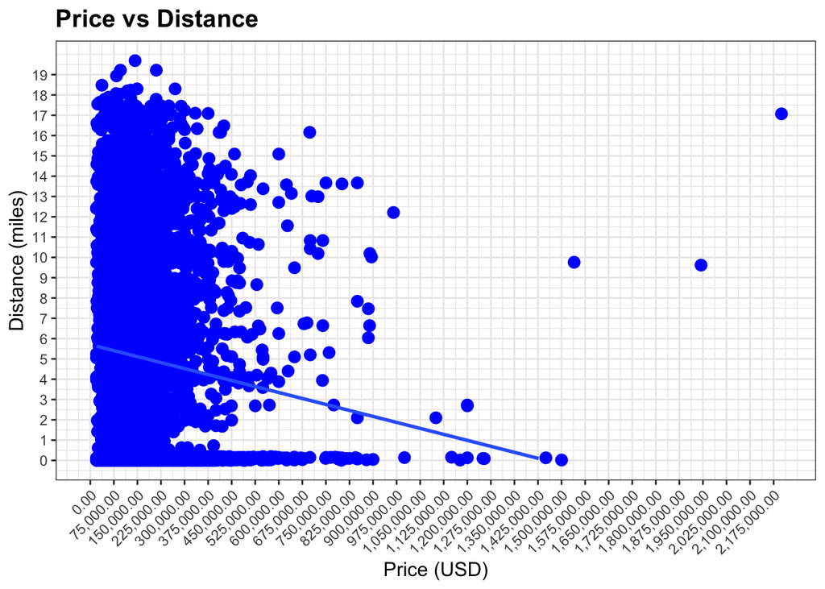

```r
# Get the maximum values
max_price <- max(price_analysis_df$Price)
max_dist <- max(price_analysis_df$Distance)

# Scatterplot of Price vs Distance
ggplot(price_analysis_df, aes(x = Price, y = Distance)) +
  geom_point(color = "blue", size = 3) +
  geom_smooth(method = "lm", se = FALSE) +
  labs(
    title = "Price vs Distance",
    x = "Price (USD)",
    y = "Distance (miles)"
  ) +
  theme_bw() +
  theme(
    plot.title = element_text(size = 15, face = "bold"),
    axis.title = element_text(size = 12)
  ) +
  scale_x_continuous(breaks = seq(0, max_price, 75000), limits = c(0, max_price), labels = comma) +
  scale_y_continuous(breaks = seq(0, max_dist, 1), limits = c(0, max_dist)) +
  theme(axis.text.x = element_text(angle = 45, hjust = 1))
```

The residual plot below shows if the residuals are randomly distributed, which is an assumption of linear regression:

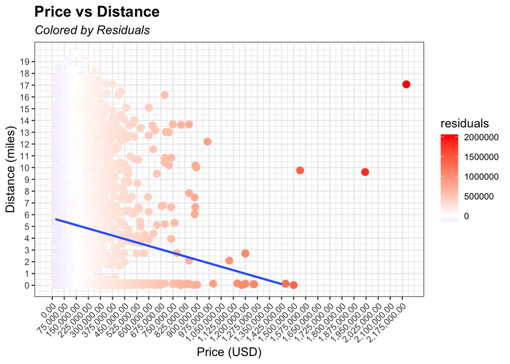

```r
# Fit a linear model
lm <- lm(Price ~ Distance, data = price_analysis_df)

# Extract the residuals
residuals <- residuals(lm)

# Get the maximum values
max_price <- max(price_analysis_df$Price)
max_dist <- max(price_analysis_df$Distance)

# Scatterplot of Price vs Distance, colored by residuals
ggplot(price_analysis_df, aes(x = Price, y = Distance, color = residuals)) +
  geom_point(size = 3) +
  geom_smooth(method = "lm", se = FALSE) +
  scale_color_gradient2(low = "blue", high = "red", mid = "white") +
  labs(
    title = "Price vs Distance",
    subtitle = "Colored by Residuals",
    x = "Price (USD)",
    y = "Distance (miles)"
  ) +
  theme_bw() +
  theme(
    plot.title = element_text(size = 15, face = "bold"),
    plot.subtitle = element_text(size = 12, face = "italic"),
    axis.title = element_text(size = 12),
    legend.title = element_text(size = 12)
  ) +
  scale_x_continuous(breaks = seq(0, max_price, 75000), limits = c(0, max_price), labels = comma) +
  scale_y_continuous(breaks = seq(0, max_dist, 1), limits = c(0, max_dist)) +
  theme(axis.text.x = element_text(angle = 45, hjust = 1))
```

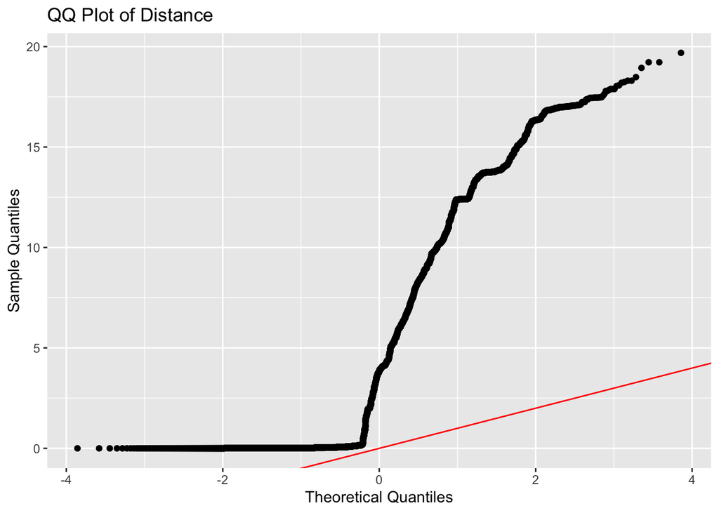

```r
# Create the QQ plot
ggplot(price_analysis_df, aes(sample = Distance)) +
  stat_qq() +
  geom_abline(color = "red") +
  xlab("Theoretical Quantiles") +
  ylab("Sample Quantiles") +
  ggtitle("QQ Plot of Distance")
```

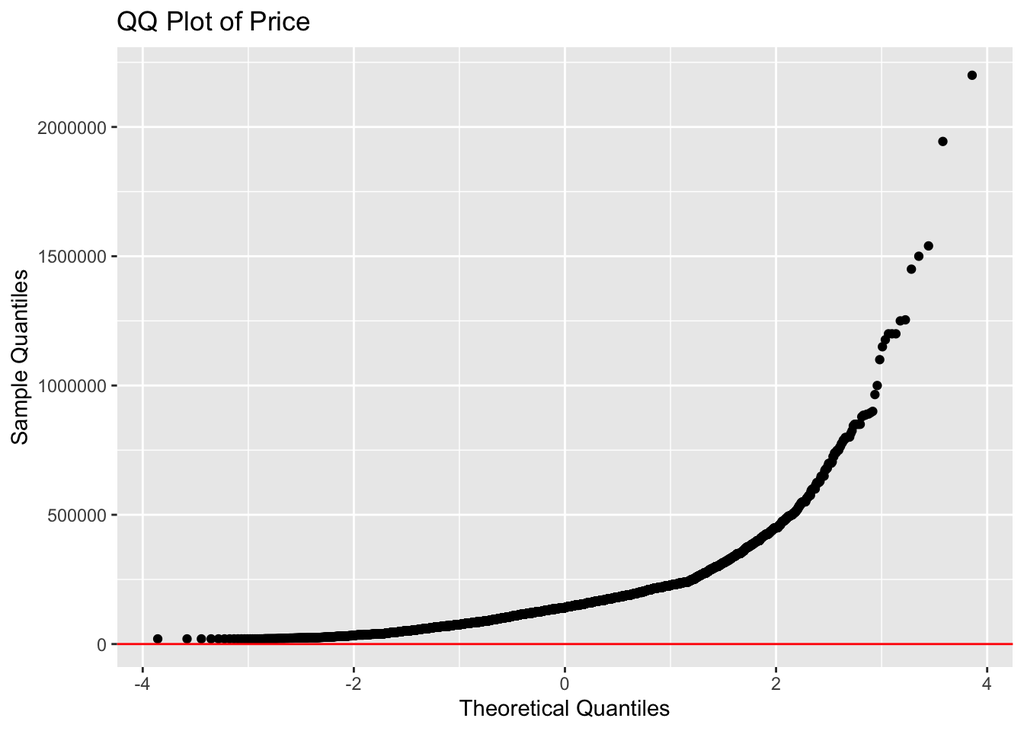

```r
ggplot(price_analysis_df, aes(sample = Price)) +
  stat_qq() +
  geom_abline(color = "red") +
  xlab("Theoretical Quantiles") +
  ylab("Sample Quantiles") +
  ggtitle("QQ Plot of Price")
```

## Results

The plots shown above give a visual representation of the relationship between Price and Distance which seems to indicate that there is a negative relationship between Price and Distance. That is, when Distance increases, Price decreases. To give a more granualr look at the relationship, a regressions table was created:

```r
# Fit linear regression model
model <- lm(Price ~ Distance, data = price_analysis_df)

# Create regression table
regression_table <- stargazer(model,
                             title = "Regression Results",
                             dep.var.labels = "Price",
                             covariate.labels = "Distance",
                             header = FALSE,
                             type = "text",
                             digits = 3)
```

```
##
## Regression Results
## ===============================================
##                         Dependent variable:
##                     ---------------------------
##                                Price
## -----------------------------------------------
## Distance                   -1,753.965***
##                              (225.344)
##
## Constant                  170,811.700***
##                             (1,663.992)
##
## -----------------------------------------------
## Observations                   8,734
## R2                             0.007
## Adjusted R2                    0.007
## Residual Std. Error   113,127.900 (df = 8732)
## F Statistic          60.583*** (df = 1; 8732)
## ===============================================
## Note:               *p<0.1; **p<0.05; ***p<0.01
```

```r
# Print regression table
cat(regression_table, sep = "\n")
```

```
##
## Regression Results
## ===============================================
##                         Dependent variable:
##                     ---------------------------
##                                Price
## -----------------------------------------------
## Distance                   -1,753.965***
##                              (225.344)
##
## Constant                  170,811.700***
##                             (1,663.992)
##
## -----------------------------------------------
## Observations                   8,734
## R2                             0.007
## Adjusted R2                    0.007
## Residual Std. Error   113,127.900 (df = 8732)
## F Statistic          60.583*** (df = 1; 8732)
## ===============================================
## Note:               *p<0.1; **p<0.05; ***p<0.01
```

The results indicated a significant negative effect of Distance on Price (-1,753.965, p < 0.01), suggesting that as the distance increased, the price decreased. However, there was some uncertainty in the estimate (standard error: 225.344).

The constant term in the regression equation represented 170,811.700 (p < 0.01), which was the expected price when the distance was zero. The R-squared value was 0.007, indicating that only 0.7% of the variation in Price was explained by Distance. The model’s predictive power was limited, as seen from the low R-squared value. The residual standard error was 113,127.900, indicating the average prediction error.

Overall, the findings suggested that Distance had a significant but weak influence on Price.

## Conclusion and Implications

# References

de Vor, F., & de Groot, H. L. (2011). The impact of industrial sites on residential property values: A hedonic pricing analysis from the Netherlands. Regional Studies, 45(5), 609–623. https://doi.org/10.1080/00343401003601925

Grislain-Letrrmy, Cc., & Katossky, A. (2014). The impact of hazardous industrial facilities on housing prices: A comparison of parametric and semiparametric hedonic price models. SSRN Electronic Journal. https://doi.org/10.2139/ssrn.2457195

Team kentucky. Team Kentucky | Cabinet for Economic Development. (n.d.). https://ced.ky.gov/ existing_industries/Major_Industries